# Лабораторная работа №15

Управление логическими томами (LVM)

Ришард Когенгар

Российский университет дружбы народов, Москва, Россия

22 января 2026

# Цель работы

## Основная цель

Получить практические навыки управления логическими томами LVM: - создание физических томов (PV), групп томов (VG) и логических томов (LV) - создание файловых систем и постоянное монтирование - изменение размеров LV с изменением размера файловой системы - проверка результатов стандартными средствами системы

# Ход выполнения работы

## Подготовка системы

- Проверены текущие точки монтирования дополнительных дисков
- В `/etc/fstab` отключены записи авто-монтирования для `/mnt/data` и `/mnt/data-ext`
- Выполнено отмонтирование ранее подключённых файловых систем
- Подтверждено отсутствие монтирования устройств `/dev/sdb` и `/dev/sdc`

[figure not shown]

## Разметка диска /dev/sdb под LVM

- Выполнена повторная разметка диска `/dev/sdb`
- Создан основной раздел **300 МБ**
- Установлен тип раздела **Linux LVM (8e)**
- Изменения записаны в таблицу разделов

[figure not shown]

## Создание физического тома (PV)

- Обновлена таблица разделов ядра
- Раздел `/dev/sdb1` инициализирован как физический том LVM
- Проверена доступность PV в системе

[figure not shown]

## Создание группы томов vgdata

- На основе PV `/dev/sdb1` создана группа томов **vgdata**
- Проверено, что PV включён в состав группы

[figure not shown]

## Создание логического тома lvdata

- В группе томов **vgdata** создан логический том **lvdata**
- Тому выделено **50% свободного пространства** группы
- Проверено наличие LV в системе

[figure not shown]

## Файловая система и постоянное монтирование /mnt/data

- На `/dev/vgdata/lvdata` создана файловая система **ext4**
- Создан каталог `/mnt/data`
- В `/etc/fstab` добавлена запись для постоянного монтирования
- Выполнена проверка успешного монтирования

[figure not shown]

## Расширение vgdata и lvdata

- Создан второй LVM-раздел на `/dev/sdb` (раздел `/dev/sdb2`)
- Раздел инициализирован как физический том
- Группа **vgdata** расширена добавлением нового PV

[figure not shown]

## Увеличение lvdata и изменение размера ФС

- Проверено увеличение свободного пространства в **vgdata**
- Логический том **lvdata** расширен на часть свободного пространства
- Размер файловой системы увеличен автоматически вместе с LV

[figure not shown]

# Самостоятельная работа

## Разметка /dev/sdc под LVM

- Для работы использован дополнительный диск `/dev/sdc`
- Созданы два основных раздела
- Для каждого раздела установлен тип **Linux LVM (8e)**
- Изменения сохранены

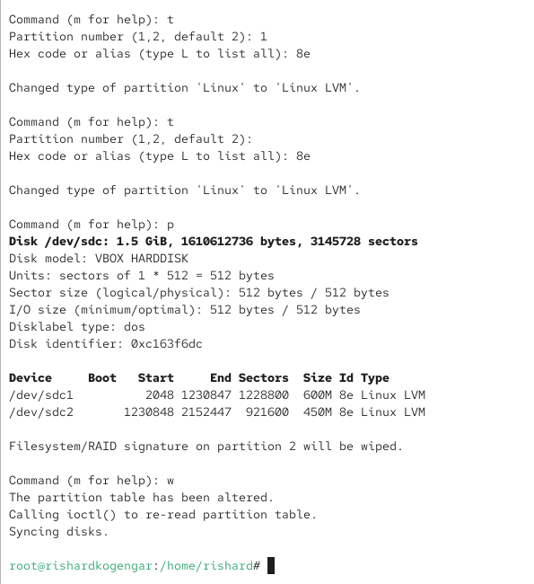

Разметка диска /dev/sdc и назначение типа Linux LVM

## Создание vggroup и lvgroup

- На `/dev/sdc1` создан физический том LVM
- Создана группа томов **vggroup**
- Создан логический том **lvgroup** в составе **vggroup**

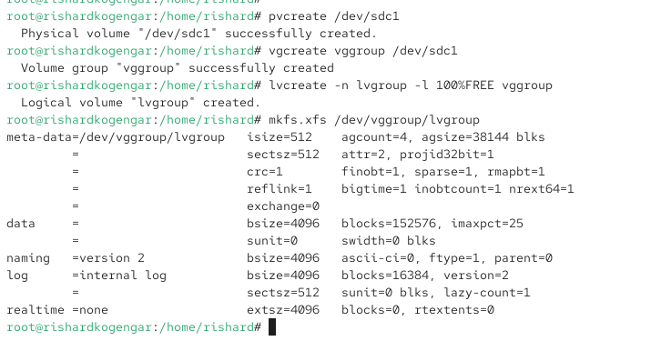

Создание физического тома, группы томов и логического тома

## Форматирование lvgroup в XFS

- Логический том `/dev/vggroup/lvgroup` отформатирован в **XFS**
- Том подготовлен для постоянного монтирования

[figure not shown]

## Постоянное монтирование /mnt/groups

- Создан каталог `/mnt/groups`
- В `/etc/fstab` добавлена запись для авто-монтирования XFS
- Проверено, что том смонтирован в `/mnt/groups`

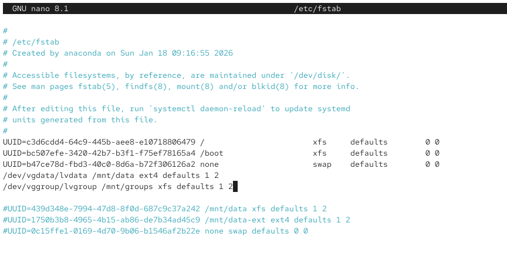

Настройка постоянного монтирования логического тома

## Проверка после перезагрузки

- Выполнена проверка монтирований в `/mnt`
- Подтверждено автоматическое подключение `lvgroup` в `/mnt/groups`
- Проверено использование дискового пространства

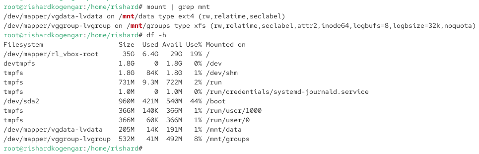

Проверка монтирования после перезагрузки

## Расширение vggroup и lvgroup

- На `/dev/sdc2` создан физический том LVM
- Группа **vggroup** расширена добавлением нового PV
- Логический том **lvgroup** расширен с автоматическим изменением размера XFS

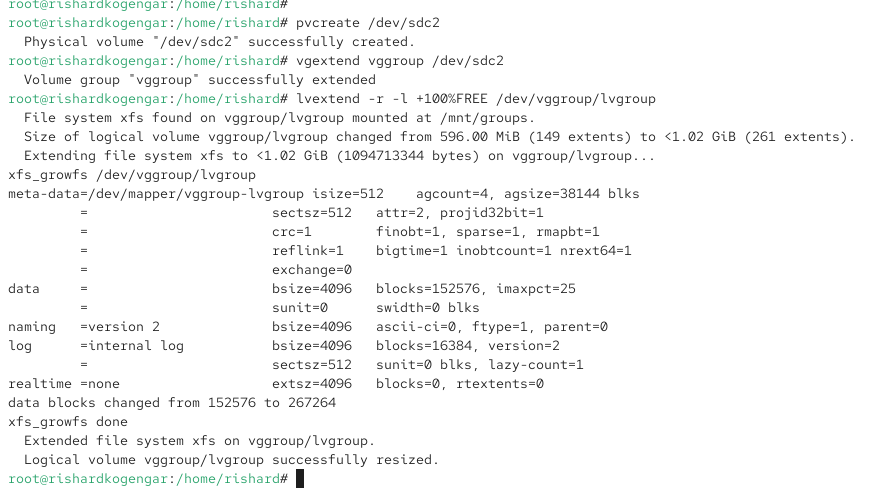

Добавление нового физического тома в группу vggroup

## Итоговая проверка расширения

- Проверены PV/VG/LV после расширения
- Подтверждено увеличение размера файловой системы в `/mnt/groups`
- Система корректно использует добавленное дисковое пространство

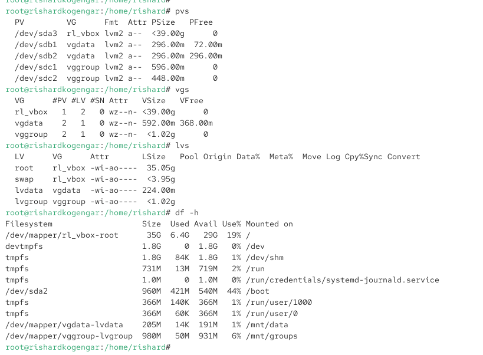

Расширение логического тома и файловой системы XFS

# Итоги работы

## Вывод

- Созданы PV, VG и LV для LVM-хранилища
- Настроены файловые системы **ext4** и **XFS** и их постоянное монтирование
- Выполнены операции увеличения и уменьшения логических томов
- Проверена корректность изменений по состоянию томов и файловых систем